# RNA-seq data processing and analyses

18 Jan 2017

## Outline

1. Why sequence the transcriptome
2. Overview of RNA-seq (From RNA to sequence)
3. RNA-seq analysis (From sequence to RNA and expression)
   - Quality control of sequence data
   - Mapping based approach
   - Transcriptome assembly
   - Estimate gene expression

## 1. Why sequence the transcriptome

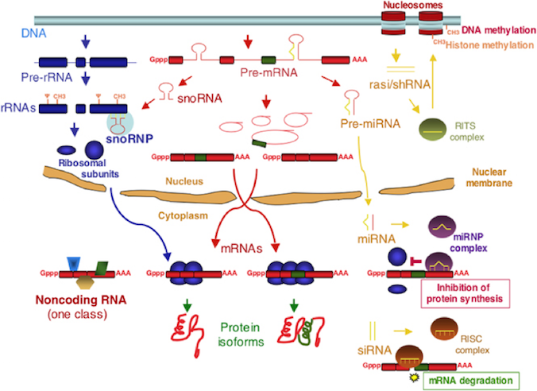

## Applications for RNA-seq

- Identify gene sequences in genomes
- Investigate patterns of gene expression
- Study isoforms and allelic expression
- Learn about gene functions
- Identify co-expressed gene networks
- Identify SNPs in genes

## What makes RNA-seq different to genome sequencing

- Dynamic expression, which means that each tissue, time-point and cell will be different
- Most data comes from "functional units" eg. protein coding genes
- Smaller sequence space as it is a subset of the complete genome

## 2. Overview of RNA-seq

### - from RNA to sequence

## What is in the sequences

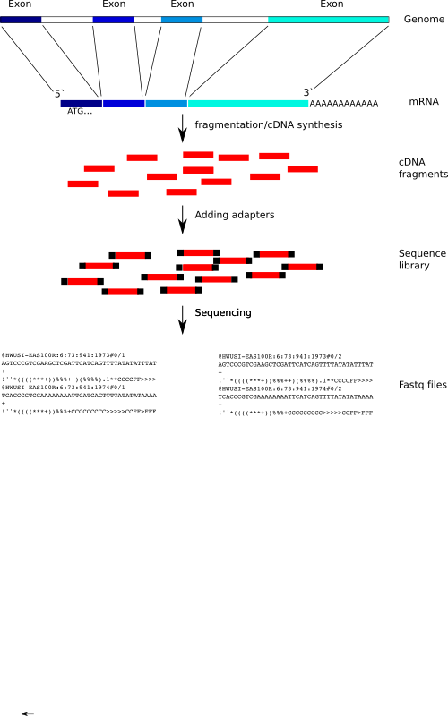

## From RNA to sequence

[figure not shown]

## High-level RNA-seq workflow

- Experimental design (biology, medicine, statistics)
- RNA Extraction (biology, biotechnology)
- Library preparation (biology, biotechnology)
- Sequencing (engineering, chemistry, physics, biotechnology and bioinformatics)
- Data processing (bioinformatics)
- Data analysis (bioinformatics, biostatistics, biology, medicine)

## Type of data

- The actual sequence data is the same as for genome sequence data
- Both single- and pair-end data
- Major difference is that transcripts often comes from one strand and most data retain this structure eg. the sequence data is from only one strand.

## RNA-seq workflow

[figure not shown]

## QC of sequence files

## Quality control of fastq files

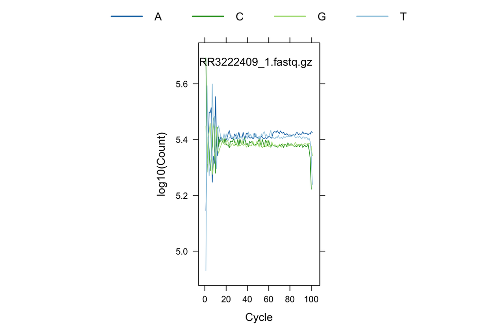

## Quality control of fastq files

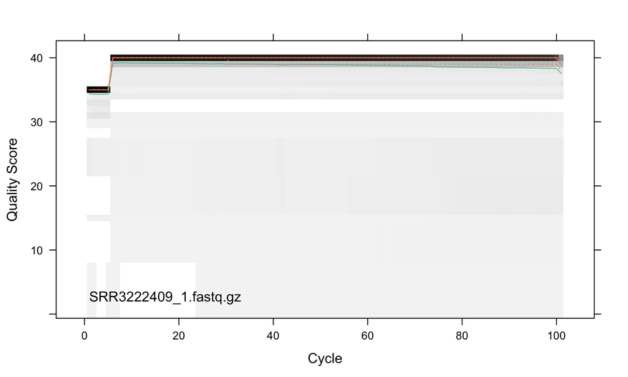

## Filter and trim fastq data

Based on the QC results there are at times a need to filter "bad" data. For example:

- filter reads based on quality score, e.g. with avg. quality below 20 within 4-basepair wide sliding windows
- filter reads that after this are shorter than a given cut-off
- remove unwanted sequences, e.g. adapter sequences or contaminants

## Tools for QC and trimming/filtering of fastq data

- fastQC (QC)
- Prinseq (QC and filtering)
- FastX-toolkit (QC and trimming/filtering)
- R, via ShortRead package (QC and trimming/filtering)
- Trimmomatic (Trimming/filtering)
- Cutadapt (Trimming/filtering)

## Reference based expression analysis

## What do need for this

- Read data (fastq files)  
  From the sequencing machines
- Reference genome (fasta file)  
  The genome sequence of the species.
- Reference annotation (GTF/GFF files)  
  Where the genes located on the genome

## Mapping reads to genomes

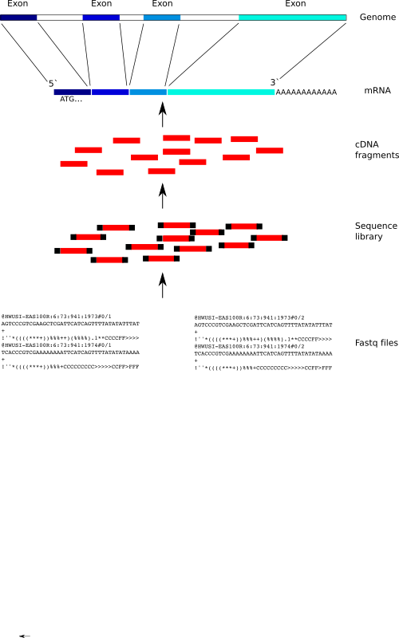

## Mapping reads to genomes

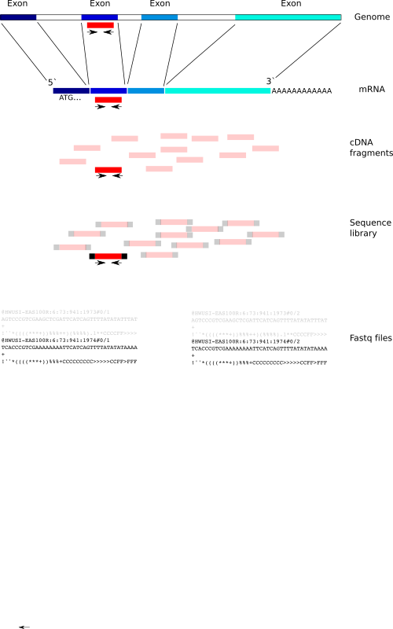

## Mapping reads to genomes

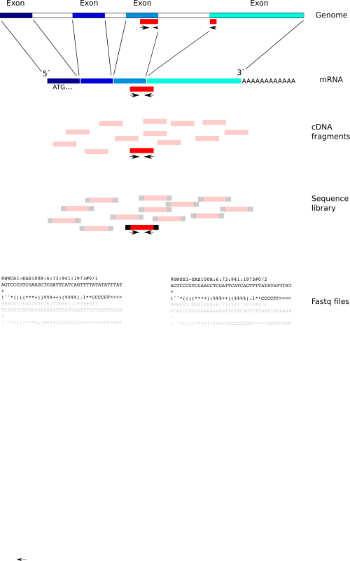

## Mapping reads

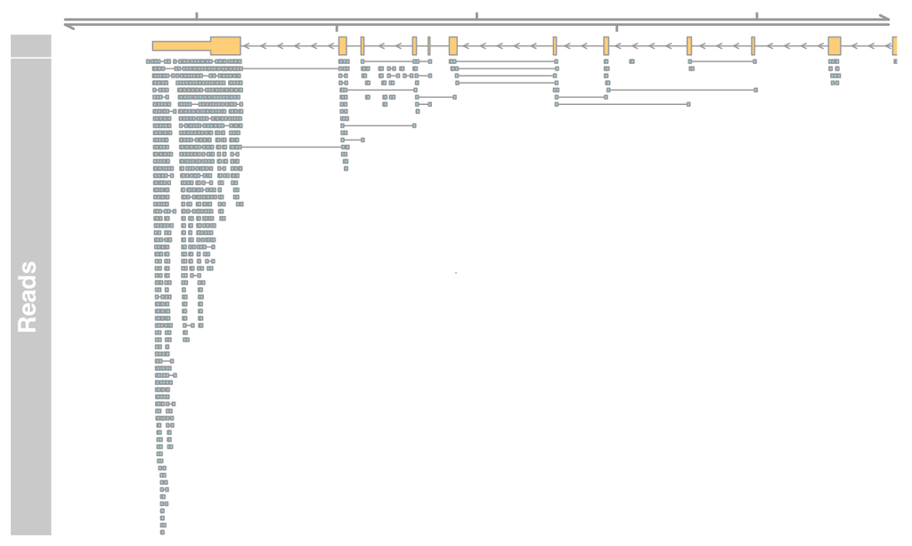

## QC of mapped data

| Group | Total bases | Tag counts | Tags/Kb |
| --- | --- | --- | --- |
| CDS Exons | 33302033 | 20002271 | 600.63 |
| 5'UTR | 21717577 | 4408991 | 203.01 |
| 3'UTR | 15347845 | 3643326 | 237.38 |
| Introns | 1132597354 | 6325392 | 5.58 |
| TSS up 1kb | 17957047 | 215331 | 11.99 |
| TES dn 1kb | 18298543 | 266161 | 14.55 |

## QC of mapped data

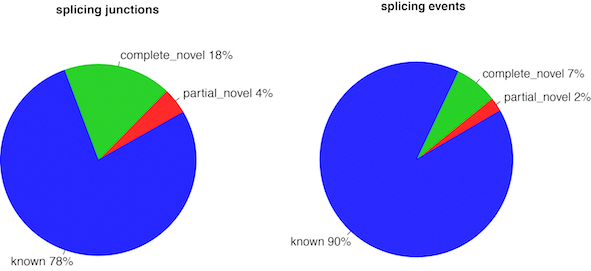

Available tools: Qualimap, RseQC, Picard, RNA-SeQC

## De-novo assembly of transriptomes

## Why?

- No reference genome available
- Identify novel transcripts (genes or splice variants)
- Identify fusion genes or transcription from unknown origin

## How?

- Assemble the transriptome from the generated short reads
- All useful methods rely on generating a structure called a de-bruijn graph that in this context aims at extenting k-mers in the short reads to longer unambiguous sequences corresponding to transcripts

## From short reads to isoforms

[figure not shown]

## Trinity

[figure not shown]

## Other useful tools

- SOAP-denovo
- TRANS Oases
- Trans-ABYSS

## QC of de-novo assemblies

- How large fractino of reads can be mapped back to the assembly
- Total sequence length of all assembled sequences
- Number of trancripts generated
- Compare to related species with genome information
- Predict open reading frames and protein domains
- etc etc

## RNA-seq for expression analysis

## From sequence to expression

- Read counts is a measure of expression level
- Many reads mapping to a genomic feature = high expression
- The expression can be quantified on any level eg. gene, transcript (isoforms), or exons.

## Counting reads

### Reference based approach

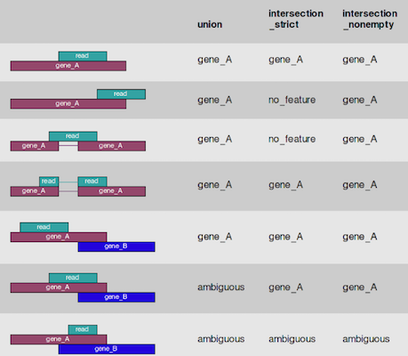

## Counting reads

### de-novo assembly

- Map reads to the assembled transcriptome
- Count reads mapping to the different transcripts that have been assembled.
- It is not as easy as it sound as transcripts can be very redundant and a read might map to multiple transcripts equally well.
- Tools available RSEM, (kallisto and salmon)

## Count matrix

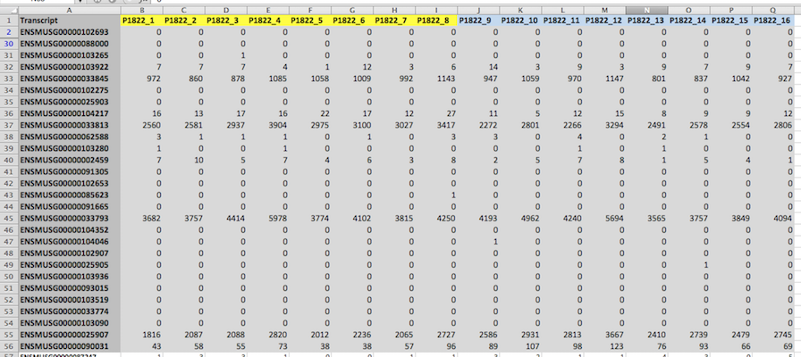

## Counts to expression

- The counts depend on both the number of sequences generated from a samples and on the sequence length of the gene/transcript
- Counts per million (CPM) is used to take out the effect of sequence depth
- Reads per kilobasepair and million (RPKM, FPKM) also takes the lengh of genes into account
- Several other normalisations are available and is used to optimize power in detection of differential expression

## Detection of differential gene expression

- Read counts (and CPM etc) does not follow a normal distribution
- In most experiments few replicates are used, limited power unless we use model based analysis for detection of DE
- It is hence recommended to use softwares designed specifically for RNA-seq DE analysis
- Some useful tools: Cuffdiff (avoid), edgeR, DESeq2, limma

## Exon use

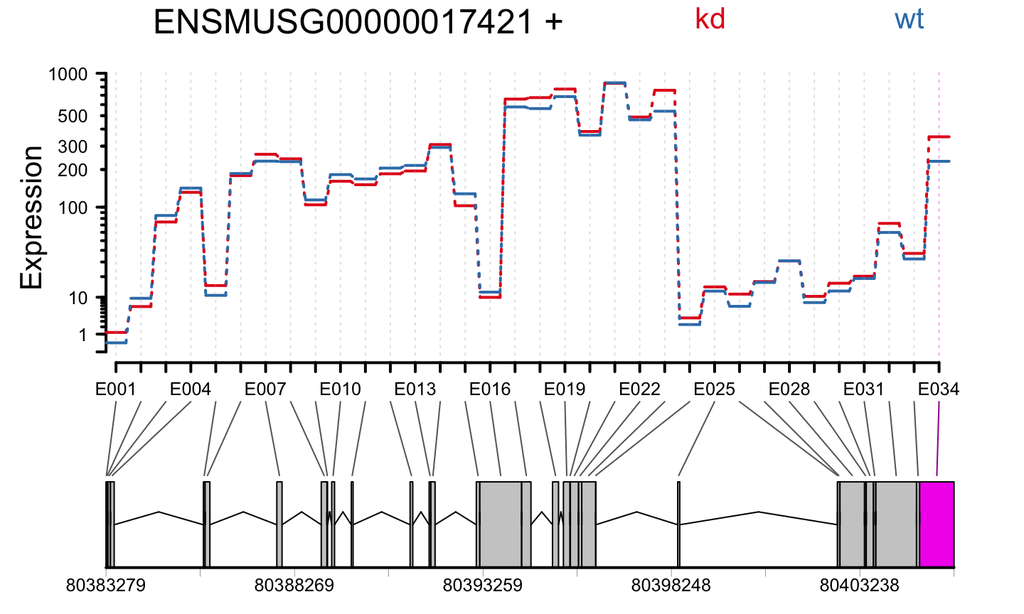

## Summary

- Many different expertises needed for RNA-seq experiments
- Think ahead, plan wisely, ask for help
- If your experimental design is wrong nothing will help
- Assess and try to improve the quality of raw reads use QC tools and talk to sequencing centre

## Summary

### Reference based

- Map to genome and use available annotations
- Count reads and check that the majority map according to expectiations
- Does count summaries make sense?
- Use appropriate tools and software for detection of DE

## Summary

### De-novo

- Use reference genome to guide it, if available
- Spend lots of time in assessing the results e.g. by comparing related species, looking at ORFs etc
- consider merging with other data sources
- Try multiple assemblers

## Gene expresssion

Ensure that your experimental design allows addressing the question of interest. More replicates translates into more power for differential gene expression and easier publication process

## Exercises for today and tomorrow

## Main exercise

### Reference based expression analysis￼

- checking the quality of the raw reads with FastQC
- map reads to the reference genome using STAR
- converting between SAM and BAM format using Samtools
- assess the post-alignment read quality using QualiMap
- count reads overlapping with gene regions using featureCounts
- Identify differentially expressed genes using a prepared r-script relying on edgeR

## Bonus exercises

### Only if times allow

- functional annotation, putting DE genes in the biological context
- exon usage, studying the alternative splicing
- data visualisation and graphics
- de novo transcriptome assembly